# Reproducible Research: Peer Assessment 1

## Imputing missing values

The missing values are replaced with the mean for the time interval across the data set. This result is then used for the subsequent analysis. A repeat of the daily analysis in Question 1 is repeated on the NA cleaned data.

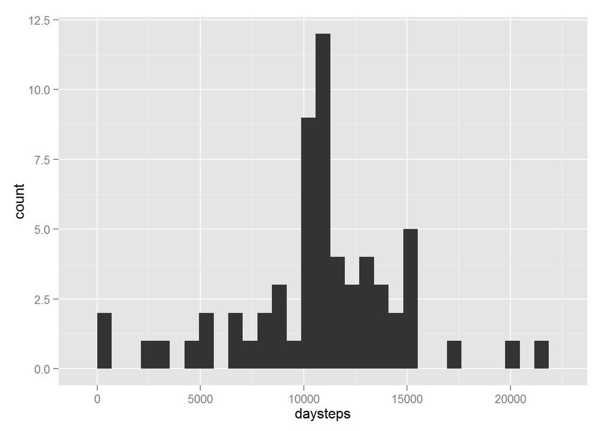

```r
countNA <- sum(is.na(activity$steps))

#replace the NA fields with the mean for that time interval using the optmatch package
impute.mean <- function(x) replace(x, is.na(x), mean(x, na.rm = TRUE))
activityNA <- ddply(activity, ~ interval, transform, stepsna = impute.mean(steps))

#copy of steps from question 1 replacing the data set for the updated NA cleaned data
dailystepsNA <- ddply(activityNA, .(date) , summarize, daysteps =sum(stepsna))
mean_daily_stepsNA <- round(mean(dailystepsNA$daysteps, na.rm = TRUE),2)
median_daily_stepsNA <- median(dailystepsNA$daysteps, na.rm = TRUE)
qplot(daysteps, data=dailystepsNA, geom='histogram')
```

```r
png("figure/dailyanalysisNA.png")
qplot(daysteps, data=dailystepsNA, geom='histogram')
dev.off()
```

```r
#print out the summary data for the analysis
summaryNA <- data.frame(countNA, mean_daily_stepsNA, median_daily_stepsNA)
print(summaryNA)
```

```
##   countNA mean_daily_stepsNA median_daily_stepsNA
## 1    2304           10766.19             10766.19
```

## Are there differences in activity patterns between weekdays and weekends?

A new 2 factor flag (‘weekendflag’) is created to separate weekdays from weekends. This field is used to create a comparasion between the steps pattern for weekdays versus weekends

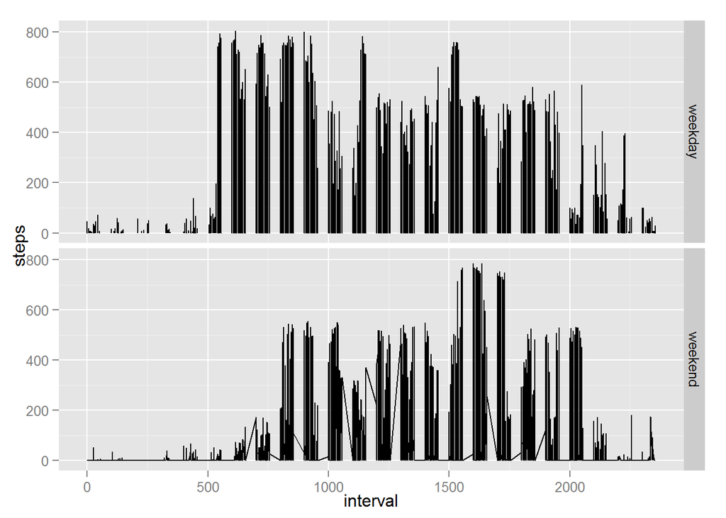

```r
#calculated the difference between weekday and weekend activity
#3 part clean up process
#   1. Convert the date field to a date class
#   2. Create the  factor flag for weekend/weekday
#   3. Convert the weekend flag to a factor class
activityNA$date <- as.Date(activityNA$date)
activityNA$weekendflag <- ifelse(weekdays(activityNA$date) %in% c('Saturday', 'Sunday'),'weekend', 'weekday')
activityNA$weekendflag <- as.factor(activityNA$weekendflag)

# Create the 2 level lattice plot using ggplot2
qplot(interval, steps, facets = weekendflag~., data=activityNA, geom= 'line')
```

```r
png("figure/weekdayNA.png")
qplot(interval, steps, facets = weekendflag~., data=activityNA, geom= 'line')
dev.off()
```

The comparasion line graphs show weekdays have higher step counts across the day, especially earlier in the day. While weekends have a similar period maximum, it happens later in the day and that maximum is not sustained for as long.